# Introdução à Regressão Linear

Monitoria em Métodos Quantitativos II

Ryan Almeida

09 fevereiro, 2026

```r
# Aviso: Essas notas de aula são exclusivas para uso como guia do curso, porém não substituem as referências e materiais de apoio. Quaisquer erros são de responsabilidade do autor.
# Esse material é protegido por ser propriedade intelectual.
# Logo, ao reproduzir, divulgar ou distribuir notifique a autoria.

# Caso encontre erros, contate os autores imediatamente. Via e-mail ryallmeida@gmail.com
```

```r
# CODADO ORIGINALMENTE EM R, V. 4.5.2
```

# 1 Prefácio

## 1.1 Sobre a apostila

Esta é uma Apostila dos códigos e suas respectivas notas utilizadas nas monitorias do curso de “Métodos Quantitativos II” ofertado pelo Departamento de Ciência Política da Universidade Federal de Pernambuco. Estas notas e considerações foram tecidas monitor [Ryan Almeida](https://github.com/ryallmeida) balisando seu horizonte de conhecimento em Estatística, Análise de Dados e Metódos Quantitativos em Ciência Política.

## 1.2 Sobre o autor

[Ryan Almeida](http://lattes.cnpq.br/8240327313395015) é graduando em Ciência Política com ênfase em Relações Internacionais pela Universidade Federal de Pernambuco (CFCH/UFPE) e, dentro da sua formação, realiza atividade de extensão, pesquisa e intervenção no Laboratório de Estudos da Sexualidade Humana (LabEshu/Dept. de Psicologia). Além disso, demonstra interesse nas áreas de métodos em Ciência Política e políticas públicas. Em virtude de sua atuação social, recebeu o Selo UNICEF (2021-2024) como Mobilizador de Adolescentes e Jovens, em reconhecimento às atividades desenvolvidas junto ao Núcleo de Cidadania dos Adolescentes (NUCA/UNICEF) de Arcoverde/PE.

# 2 Notas sobre à Regressão Linear propriamente dita

Este é um método para modelar o relacionamento entre duas ou mais variáveis e serve para prever a variável resposta (y) com base nos valores das variáveis preditoras (x), a fim de quantificar a força dessa relação.

A equação

$$\hat{Y}_i = \hat{\beta}_0 + \sum_{j=1}^{k} \hat{\beta}_j X_{ji} +
\varepsilon_i$$

representa um **modelo de regressão linear múltipla** e descreve como o valor estimado de uma variável dependente é explicado por um conjunto de variáveis independentes.

Em primeiro lugar, $\hat{Y}_i$ indica o valor estimado da variável resposta para o indivíduo (ou observação) $i$. Trata-se do resultado que o modelo prevê com base nas informações disponíveis, e não do valor observado diretamente nos dados. O uso do “chapéu” (^) sinaliza que se trata de uma estimativa produzida pelo modelo estatístico.

O termo $\hat{\beta}_0$ é o intercepto da regressão. Ele representa o valor esperado de $Y$ quando todas as variáveis explicativas $X_{ji}$ assumem valor zero. Em termos substantivos, o intercepto pode ser interpretado como um ponto de referência ou condição basal, ainda que, em muitos contextos empíricos, essa situação (todas as variáveis iguais a zero) não seja realista. Mesmo assim, o intercepto é fundamental para posicionar corretamente a reta (ou hiperplano) de regressão.

O somatório

$$\sum_{j=1}^{k} \hat{\beta}_j X_{ji}$$

expressa a contribuição conjunta das $k$ variáveis independentes para explicar Y. Cada coeficiente $\hat{\beta}_j$ indica o efeito médio associado à variável $X_j$, mantendo todas as demais constantes. Em termos interpretativos, $\hat{\beta}_j$ informa quanto se espera que $\hat{Y}_i$ varie quando $X_{ji}$ aumenta uma unidade, assumindo que as outras variáveis do modelo não se alterem. Assim, os coeficientes capturam relações parciais, e não efeitos brutos ou isolados.

O termo $\varepsilon_i$ representa o erro aleatório ou resíduo associado à observação i. Ele corresponde à parcela de $Y_i$ que não é explicada pelas variáveis incluídas no modelo. Em termos substantivos, o erro agrega fatores não observados, imprecisões de medida e variações aleatórias inevitáveis nos fenômenos sociais e empíricos.

Ao interpretar o resultado de uma regressão linear, o foco recai principalmente sobre os coeficientes $\hat{\beta}_j$, seus sinais (positivos ou negativos), suas magnitudes e sua significância estatística. Um coeficiente positivo indica uma associação direta entre a variável explicativa e a variável dependente; um coeficiente negativo indica uma associação inversa. A significância estatística, por sua vez, informa se o efeito estimado é suficientemente distinto de zero para que não seja atribuído apenas ao acaso, dado um nível de confiança pré-estabelecido.

Além dos coeficientes individuais, a regressão deve ser interpretada de forma global, observando-se medidas de ajuste do modelo, como o $R^2$, que indica a proporção da variância de (Y) explicada pelo conjunto das variáveis independentes. Em conjunto, esses elementos permitem avaliar tanto a força explicativa do modelo quanto a plausibilidade substantiva das relações estimadas.

Não esqueça: a violação dos pressupostos da regressão pode levar a estimativas enviesadas, erros-padrão incorretos, testes t e f inválidos, e conclusões estatísticas equivocadas.

[output not shown]

```r
# CARREGANDO DADOS

dados <- WDI(
  country = "all",
  indicator = c(
    pib = "NY.GDP.PCAP.KD",
    vida = "SP.DYN.LE00.IN",
    desemprego = "SL.UEM.TOTL.ZS"
  ),
  start = 2000,
  end = 2020
)

dplyr::glimpse(dados)
```

```
## Rows: 5,586
## Columns: 7
## $ country    <chr> "Afghanistan", "Afghanistan", "Afghanistan", "Afghanistan",…
## $ iso2c      <chr> "AF", "AF", "AF", "AF", "AF", "AF", "AF", "AF", "AF", "AF",…
## $ iso3c      <chr> "AFG", "AFG", "AFG", "AFG", "AFG", "AFG", "AFG", "AFG", "AF…
## $ year       <int> 2000, 2001, 2002, 2003, 2004, 2005, 2006, 2007, 2008, 2009,…
## $ pib        <dbl> 308.3183, 277.1181, 338.1400, 346.0716, 338.6373, 363.6401,…
## $ vida       <dbl> 55.00500, 55.51100, 56.22500, 57.17100, 57.81000, 58.24700,…
## $ desemprego <dbl> 7.897000, 7.973000, 7.867000, 7.844000, 7.794000, 7.878000,…
```

```r
# TESTANDO A PRESENÇA DE NAs

summary(dados$pib)
```

```
##    Min. 1st Qu.  Median    Mean 3rd Qu.    Max.    NA's
##     233    1709    5134   14100   17775  185583     237
```

```r
summary(dados$vida)
```

```
##    Min. 1st Qu.  Median    Mean 3rd Qu.    Max.    NA's
##   14.66   64.80   71.77   70.22   76.70   86.15      21
```

```r
summary(dados$desemprego)
```

```
##    Min. 1st Qu.  Median    Mean 3rd Qu.    Max.    NA's
##   0.100   4.164   6.356   7.854   9.993  37.320     651
```

```r
# NOTE A PRESENÇA DE NAS NO OUTPUT QUE SEGUE
```

Uma possibilidade de tratamento pode-se ser via do critério do intervalo interquartil (IQR), considerando como observações extremas os valores situados abaixo de Q1 − 1,5×IQR ou acima de Q3 + 1,5×IQR. O método do IQR é robusto a distribuições não normais e reduz a influência desproporcional de valores extremos sobre medidas de associação, como coeficientes de correlação, contribuindo para maior estabilidade estatística dos resultados.

```r
# VAMOS IGNORAR OS VALORES AUSENTES, TRATAMENTO VIA LIMPEZA POR IQR

remove_outliers_iqr <- function(x) {
  q1 <- quantile(x, 0.25, na.rm = TRUE)
  q3 <- quantile(x, 0.75, na.rm = TRUE)
  iqr <- q3 - q1

  x >= (q1 - 1.5 * iqr) & x <= (q3 + 1.5 * iqr)
}

dados_sem_outliers <- dados %>%
  filter(
    remove_outliers_iqr(pib),
    remove_outliers_iqr(vida),
    remove_outliers_iqr(desemprego)
  )
```

```r
# TESTANDO A PRESENÇA DE NAs

summary(dados_sem_outliers$pib)
```

```
##    Min. 1st Qu.  Median    Mean 3rd Qu.    Max.
##     233    1382    3922    8391   10022   41798
```

```r
sd(dados_sem_outliers$pib)
```

```
## [1] 10461.52
```

```r
summary(dados_sem_outliers$vida)
```

```
##    Min. 1st Qu.  Median    Mean 3rd Qu.    Max.
##   47.03   63.32   70.54   69.03   75.05   85.50
```

```r
sd(dados_sem_outliers$vida)
```

```
## [1] 8.150504
```

```r
summary(dados_sem_outliers$desemprego)
```

```
##    Min. 1st Qu.  Median    Mean 3rd Qu.    Max.
##   0.119   4.085   6.224   6.985   9.189  18.724
```

```r
sd(dados_sem_outliers$desemprego)
```

```
## [1] 3.956368
```

```r
# OUTRA POSSIBILIDADE É IMPUTAÇÃO DOS DADOS VIA COMPORTAMENTO DE ESTATÍSTICAS DESCRITIVAS

dados_imputados <- dados %>%
  mutate(
    bienio = year - (year %% 2)
  ) %>%
  group_by(bienio) %>%
  mutate(
    pib = if_else(
      is.na(pib),
      mean(pib, na.rm = TRUE),
      pib
    ),
    vida = if_else(
      is.na(vida),
      mean(vida, na.rm = TRUE),
      vida
    ),
    desemprego = if_else(
      is.na(desemprego),
      mean(desemprego, na.rm = TRUE),
      desemprego
    )
  ) %>%
  ungroup() %>%
  select(-bienio)
```

```r
# TESTANDO A PRESENÇA DE NAs

summary(dados_imputados$pib)
```

```
##    Min. 1st Qu.  Median    Mean 3rd Qu.    Max.
##     233    1823    5640   14082   16443  185583
```

```r
sd(dados_imputados$pib)
```

```
## [1] 20469.92
```

```r
summary(dados_imputados$vida)
```

```
##    Min. 1st Qu.  Median    Mean 3rd Qu.    Max.
##   14.66   64.84   71.76   70.22   76.68   86.15
```

```r
sd(dados_imputados$vida)
```

```
## [1] 8.68277
```

```r
summary(dados_imputados$desemprego)
```

```
##    Min. 1st Qu.  Median    Mean 3rd Qu.    Max.
##   0.100   4.438   7.127   7.854   9.211  37.320
```

```r
sd(dados_imputados$desemprego)
```

```
## [1] 5.170459
```

# 3 Correlação

```r
# PACOTE PARA ANÁLISE DE CORRELAÇÃO
pacman::p_load(corrplot)
```

## 3.1 Correlação de Pearson

Quais são os pressupostos da Correlação de Pearson? Normalidade via Teste Shapiro-Wilk, presença de Outliers e relação linear entre as variáveis

```r
# TESTE DE NORMALIDADE
# TESTE DE HIPÓTESES

# ONDE A HIPOTESE NULA (H0) É QUE OS DADOS SEGUEM A DISTRIBUIÇÃO NORMAL (PARA VALORES MAIORES QUE 5% NO P-VALUE), E A HIPOTESE ALTERNATIVA (H1) É QUE A DISTRIBUIÇÃO É DIFERENTE DA NORMAL (PARA VALORES MENORES QUE 5% NO P-VALUE)

shapiro.test(dados_sem_outliers$pib)
```

```
##
##  Shapiro-Wilk normality test
##
## data:  dados_sem_outliers$pib
## W = 0.72967, p-value < 2.2e-16
```

```r
shapiro.test(dados_sem_outliers$vida)
```

```
##
##  Shapiro-Wilk normality test
##
## data:  dados_sem_outliers$vida
## W = 0.96596, p-value < 2.2e-16
```

```r
shapiro.test(dados_sem_outliers$desemprego)
```

```
##
##  Shapiro-Wilk normality test
##
## data:  dados_sem_outliers$desemprego
## W = 0.95039, p-value < 2.2e-16
```

```r
# NENHUMA DAS ALTERNATIVAS ACIMA TÊM DISTRIBUIÇÃO NORMAL
```

### 3.1.1 Presença de outliers

#### 3.1.1.1 PIB

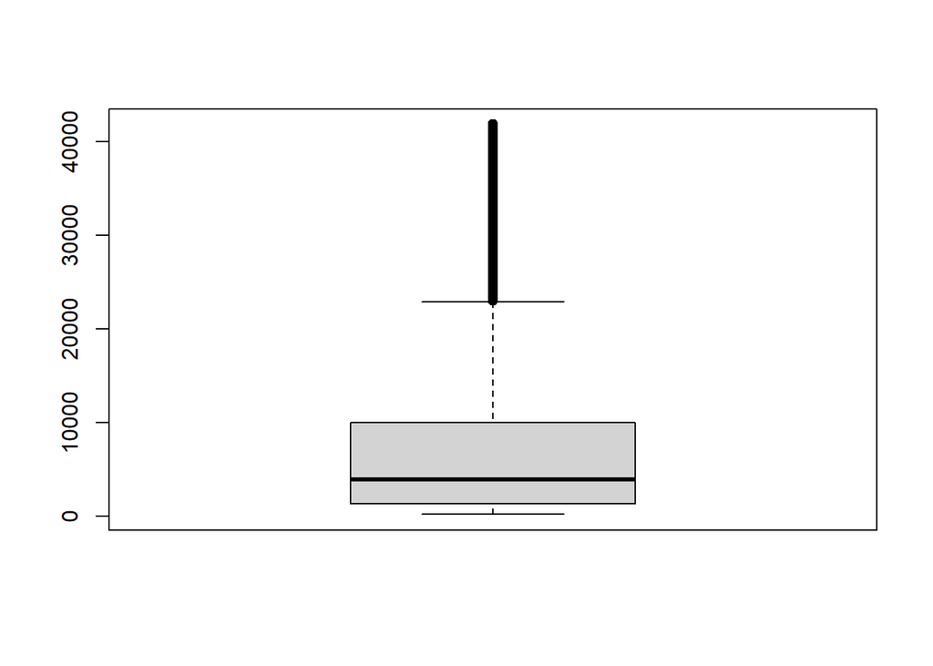

```r
boxplot(dados_sem_outliers$pib)
```

#### 3.1.1.2 Expectativa de vida

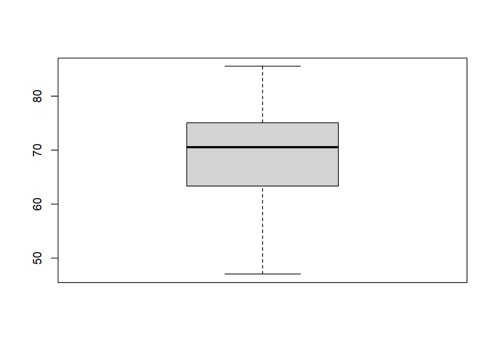

```r
boxplot(dados_sem_outliers$vida)
```

#### 3.1.1.3 Desemprego

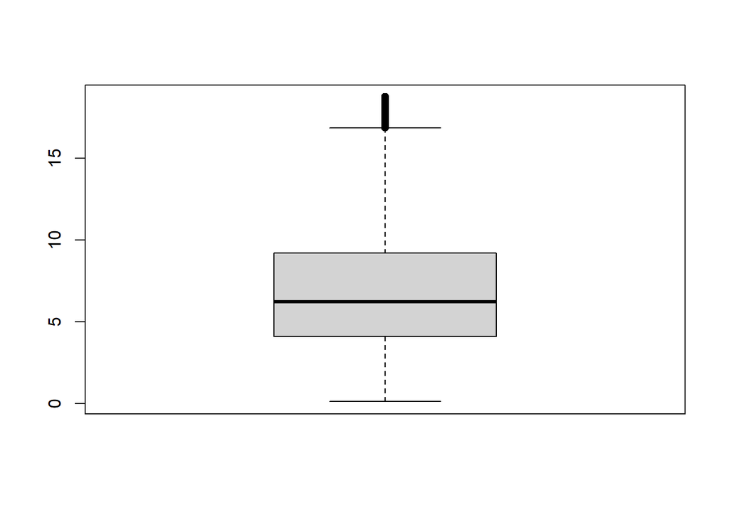

```r
boxplot(dados_sem_outliers$desemprego)
```

### 3.1.2 Relação linear entre variáveis

#### 3.1.2.1 Arranjo 1

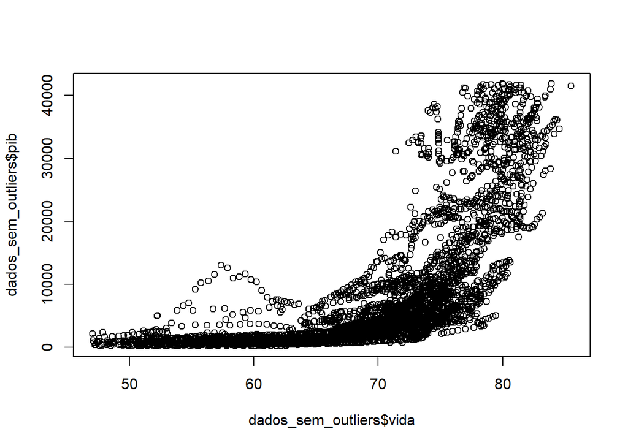

```r
plot(dados_sem_outliers$vida, dados_sem_outliers$pib)
```

#### Arranjo 2

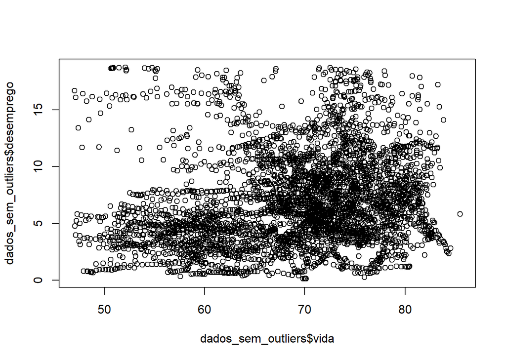

```r
plot(dados_sem_outliers$vida, dados_sem_outliers$desemprego)
```

#### 3.1.2.2 Arranjo 3

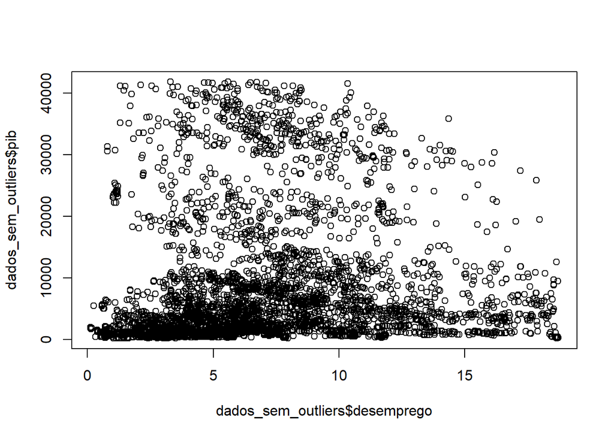

```r
plot(dados_sem_outliers$desemprego, dados_sem_outliers$pib)
```

## 3.2 Correlação de Spearman

## 3.3 Correlação de Kendall

# 4 Métodos dos Mínimos Quadrados Ordinários

O Método dos Mínimos Quadrados Ordinários (MQO) é o fundamento matemático e estatístico que permite transformar um conjunto de dados observados em um modelo linear estimado. A sua importância decorre do fato de que ele fornece um critério claro, operacional e teoricamente justificado para escolher os coeficientes $\beta_0, \beta_1, \ldots, \beta_k$ que melhor descrevem a relação entre as variáveis.

A primeira expressão

$$\min_{\beta_0, \beta_1, \dots, \beta_k}\sum_{i=1}^{n}\left( Y_i -
\beta_0 - \sum_{j=1}^{k} \beta_j X_{ji} \right)^2$$

define o **problema de otimização central do MQO**. O que se busca é encontrar os valores dos parâmetros que minimizam a soma dos quadrados dos resíduos. O termo entre parênteses representa a diferença entre o valor observado (Y_i) e o valor ajustado pelo modelo linear. Ao elevar essa diferença ao quadrado, o método garante que erros positivos e negativos não se anulem e, ao mesmo tempo, penaliza erros grandes de forma mais severa do que erros pequenos. Assim, o MQO escolhe os coeficientes que produzem, no conjunto, o **melhor ajuste médio possível** aos dados.

A importância dessa minimização está no fato de que ela fornece uma **regra objetiva** para estimar os parâmetros. Não se trata de um ajuste visual ou arbitrário, mas de uma solução única (sob condições padrão) derivada de um critério matemático explícito. Em termos geométricos, o MQO projeta o vetor de valores observados (Y) sobre o espaço gerado pelas variáveis explicativas, garantindo que os resíduos sejam ortogonais a esse espaço. Isso confere ao modelo uma propriedade central: não há informação linear adicional nas variáveis explicativas que possa reduzir ainda mais os erros.

A segunda expressão

$$\hat{\varepsilon}_i = Y_i - \hat{\beta}_0 - \sum_{j=1}^{k} \hat{\beta}_j
X_{ji}$$

define o resíduo estimado para cada observação. O resíduo mede exatamente aquilo que o modelo não consegue explicar. A importância desse termo é dupla. Primeiro, ele permite avaliar a qualidade do ajuste, pois resíduos pequenos indicam que o modelo descreve bem os dados, enquanto resíduos grandes sugerem omissões, má especificação ou alta variabilidade não explicada. Segundo, os resíduos são a base para toda a inferência estatística associada à regressão: testes de hipóteses, intervalos de confiança e diagnósticos do modelo dependem diretamente do seu comportamento.

Do ponto de vista teórico, o MQO é especialmente importante porque, sob hipóteses relativamente fracas (linearidade, exogeneidade, variância constante e ausência de multicolinearidade perfeita), os estimadores obtidos possuem propriedades desejáveis. Eles são não viesados, consistentes e, pelo Teorema de Gauss–Markov, apresentam a menor variância possível entre todos os estimadores lineares não viesados. Isso significa que, dentro dessa classe, nenhum outro método produz estimativas mais precisas em média.

Além disso, o MQO cria uma ponte direta entre álgebra, geometria e estatística aplicada. Ele pode ser interpretado como um problema de minimização, como uma projeção em espaços vetoriais ou como um procedimento inferencial probabilístico.

Em síntese, a importância dos Mínimos Quadrados Ordinários reside em três aspectos centrais: ele fornece um critério matemático rigoroso para estimar coeficientes, permite quantificar sistematicamente o erro por meio dos resíduos e garante propriedades estatísticas ótimas sob condições bem definidas.

### 4.0.1 Modelo com R2 alto

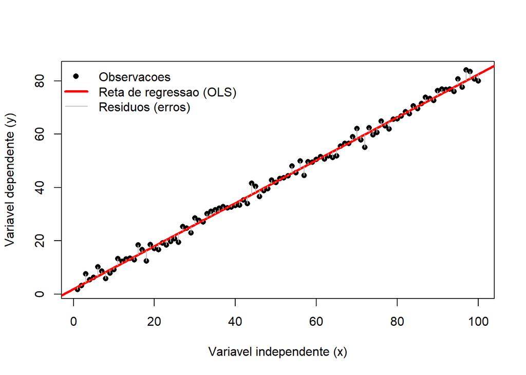

### 4.0.2 Modelo de R2 mais baixo

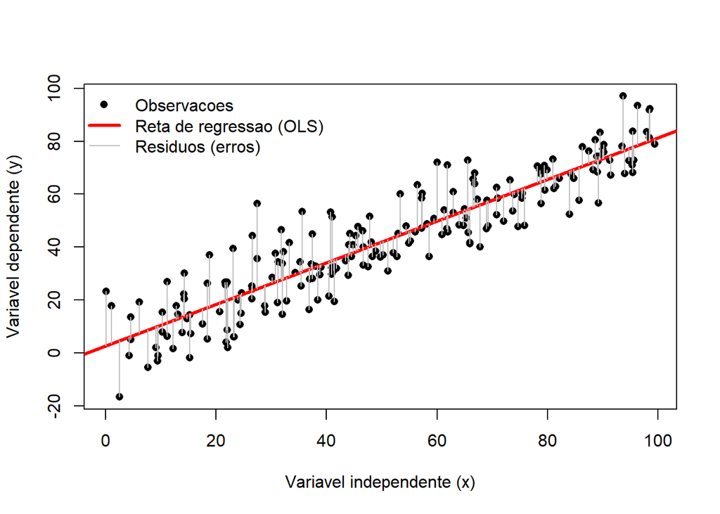

# 5 Análise dos resíduos: a diagnose do modelo

## 5.3 Outliers, pontos de alavancagem e distância de Cook

# 6 Generalized Linear Models (GLMs)

# 7 Modelos Não-lineares

# 8 Referências